# Chapter code for Applied Predictive Modeling (Kuhn and Johnson, 2013)

Chapter 13

by Brian Hassett

# 13 Nonlinear Classification Models

This is a `tidymodels` implementation of the code in **Chapter 13** of **Applied Predictive Modeling** by Max Kuhn and Kjell Johnson[^1].

Each model is implemented in its own section, including preprocessing and tuning. The models are then collectively assessed in the **Metrics** section, which includes ROC curves and lift/gain charts for each model.

## Setup

```r
# Load packages:
library(tidyverse)
library(tidymodels)
library(discrim)
library(ggcorrplot)
library(patchwork)

# Load my functions:
source("/home/brian/R/dir/Util/bh_functions.R")

# Options:
theme_set(theme_bw())
options(digits = 4)
```

## Load Data

```r
# Prepare data:
df <- read_csv("/home/brian/R/dir/APM/chapter12/data/crx.data", col_names = F, na = '?') %>%
  mutate(y = factor(X16),
         X11 = parse_number(X11),     # this should be continuous according to the description
         X14 = parse_number(X14)) %>% # this should be continuous according to the description
  # Using '+' and '-' causes problems for R so switch to simple strings;
  mutate(y = factor(if_else(y == "+", "yes", "no"), levels = c("yes", "no"))) %>%
  # drop the original response, X16;
  dplyr::select(y, everything(), -X16)

# Remove missing data (small amount):
df <- na.omit(df)

# View data:
df
```

| y | X1 | X2 | X3 | X4 | X5 | X6 | X7 | X8 | X9 | X10 | X11 | X12 | X13 | X14 | X15 |
| --- | --- | --- | --- | --- | --- | --- | --- | --- | --- | --- | --- | --- | --- | --- | --- |
| yes | b | 30.83 | 0.000 | u | g | w | v | 1.250 | TRUE | TRUE | 1 | FALSE | g | 202 | 0 |
| yes | a | 58.67 | 4.460 | u | g | q | h | 3.040 | TRUE | TRUE | 6 | FALSE | g | 43 | 560 |
| yes | a | 24.50 | 0.500 | u | g | q | h | 1.500 | TRUE | FALSE | 0 | FALSE | g | 280 | 824 |
| yes | b | 27.83 | 1.540 | u | g | w | v | 3.750 | TRUE | TRUE | 5 | TRUE | g | 100 | 3 |
| yes | b | 20.17 | 5.625 | u | g | w | v | 1.710 | TRUE | FALSE | 0 | FALSE | s | 120 | 0 |
| yes | b | 32.08 | 4.000 | u | g | m | v | 2.500 | TRUE | FALSE | 0 | TRUE | g | 360 | 0 |
| yes | b | 33.17 | 1.040 | u | g | r | h | 6.500 | TRUE | FALSE | 0 | TRUE | g | 164 | 31285 |
| yes | a | 22.92 | 11.585 | u | g | cc | v | 0.040 | TRUE | FALSE | 0 | FALSE | g | 80 | 1349 |
| yes | b | 54.42 | 0.500 | y | p | k | h | 3.960 | TRUE | FALSE | 0 | FALSE | g | 180 | 314 |
| yes | b | 42.50 | 4.915 | y | p | w | v | 3.165 | TRUE | FALSE | 0 | TRUE | g | 52 | 1442 |

[output cut: 643 more lines]

## Data Splitting

```r
# Splits
set.seed(1)
splits <- initial_split(df, strata = y) # default prop is 3/4
df_train <- training(splits)
df_test <- testing((splits))

# CV Folds:
set.seed(123)
folds <- vfold_cv(data = df_train, v = 5)
```

## Data Summary

```r
bh_print_data_summary(df)
```

```
                      [,1]
num_rows              "   653"
num_cols              "    16"
num_categorical_cols  "    10"
num_numeric_cols      "     6"
all_missing_cols      "     0"
complete_cols         "    16"
total_missing         "     0"
total_percent_missing "     0"
total_data_points     "10,448"
size_bytes            "81,296"
```

## Distribution of Response Class

Plot the response class:

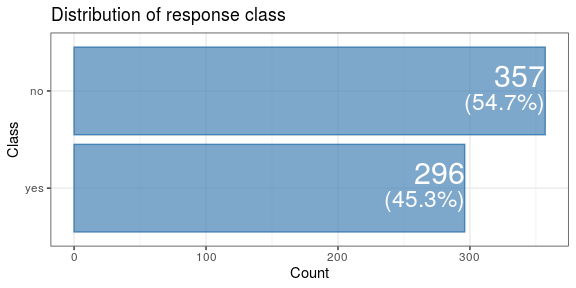

```r
df %>%
  count(y) %>%
  mutate(prop = round(100*n/sum(n), 1)) %>%
  ggplot() +
  geom_col(aes(y, n),
           fill = "steelblue", color = "steelblue", alpha = 0.7) +
  geom_text(aes(y, n, label = n), # count
            hjust = 1, vjust = -0.2, size = 8,
            color = "white") +
  geom_text(aes(y, n, label = paste0("(", prop, "%)")), # prop
            hjust = 1, vjust = 1.2, size = 6,
            color = "white") +
  labs(x = "Class", y = "Count",
       title = "Distribution of response class") +
  coord_flip()
```

The response class is relatively balanced.

## Histograms of Numeric Predictors

Plot histograms of numeric predictors:

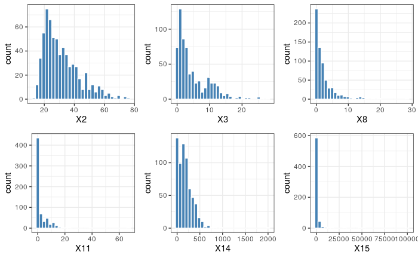

## Bar plots of categorical variables

Plot bar plots of categorical variables:

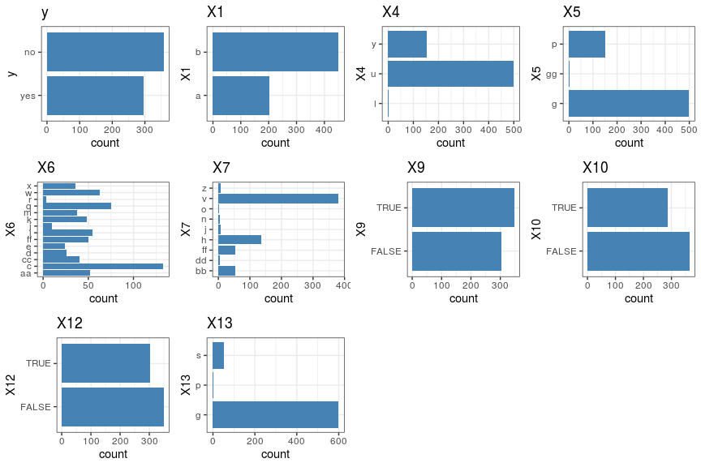

There are some sparse levels. Converting to dummy variables will likely help with this.

## Predictor Correlations

Plot the between-predictor correlations:

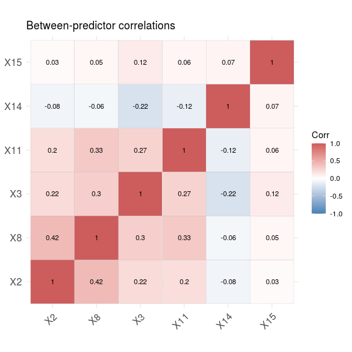

## 13.1 Nonlinear Discriminant Analysis

### Mixture Discriminant Analysis

There is no MDA implementation in `tidymodels` as yet.

### Quadratic Discriminant Analysis

QDA is a special case of regularized discriminant analysis.

To implement QDA the function `discrim_regularized()` is used with the `frac_common_cov` parameter set to 0. A value of 1 for this parameter is equivalent to LDA, and zero means there are fully separate covariance matrices for each class, which is the definition of QDA.

No resampling is used. I will `fit()` a model on the training data and make predictions on the test data.

#### Training data

```r
# Preprocessing
rec1 <-
  recipe(y ~ ., data = df_train) %>%
  step_center(all_numeric()) %>%
  step_scale(all_numeric()) %>%
  step_nzv(all_predictors()) %>%
  step_corr(all_numeric(), threshold = 0.9) %>%
  step_dummy(all_nominal(), -all_outcomes())

# Model
qda_mod <-
  discrim_regularized(frac_common_cov = 0) %>%
  set_mode("classification") %>%
  set_engine("klaR") # this engine is required here

# Workflow
workflow <-
  workflow() %>%
  add_recipe(rec1) %>%
  add_model(spec = qda_mod)

# Fit
qda_fit <-
  workflow %>%
  fit(data = df_train)

# View fit:
qda_fit %>%
  pull_workflow_fit()
```

```
parsnip model object

Fit time:  2.3s
Call:
rda(formula = ..y ~ ., data = data, lambda = ~0)

Regularization parameters:
  gamma  lambda
0.02225 0.00000

Prior probabilities of groups:
   yes     no
0.4531 0.5469

Misclassification rate:
       apparent: 18.571 %
cross-validated: 21.664 %
```

#### Test data

```r
# Fit final model and make predictions:
final_fit <-
  workflow %>%
  last_fit(splits)

# Collect predictions:
test_results <-
  final_fit %>%
  collect_predictions()
test_results$model <- "QDA"
```

### Regularized LDA

This model is implemented by using the parameters `frac_common_cov` and `frac_identity` in the `discrim_regularized()` function. We will use cross-validation to tune the parameters.

For preprocessing, I will remove NZV variables and highly correlated variables. I will also center and scale the variables.

#### Training data

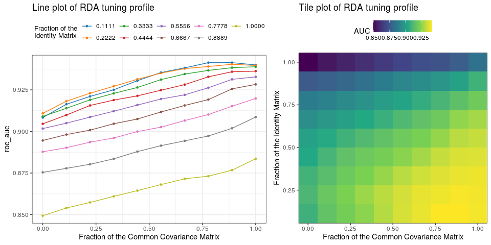

```r
# Preprocessing
rec1 <-
  recipe(y ~ ., data = df_train) %>%
  step_center(all_numeric()) %>%
  step_scale(all_numeric()) %>%
  step_nzv(all_predictors()) %>%
  step_corr(all_numeric(), threshold = 0.9) %>%
  step_dummy(all_nominal(), -all_outcomes())

# Model
regularized_lda_mod1 <-
  discrim_regularized(frac_common_cov = tune(), frac_identity = tune()) %>%
  set_mode("classification") %>%
  set_engine("klaR")

# Tuning grid
grid1 <- grid_regular(list(frac_common_cov = frac_common_cov(), frac_identity = frac_identity()), levels = 10)

# Workflow
workflow <-
  workflow() %>%
  add_model(spec = regularized_lda_mod1) %>%
  add_recipe(rec1)

# Tune
### Read in cached results if available:
file1 <- "/home/brian/R/dir/APM/chapter13/objects/regularized_lda_res1_clean.RDS"
if (file.exists(file1)) {
  regularized_lda_res1 <- readRDS(file1)
} else {
  regularized_lda_res1 <-
    workflow %>%
    tune_grid(resamples = folds, grid = grid1)
  saveRDS(regularized_lda_res1, file1)
}

# Plot AUC:
## Line plot:
p1 <- autoplot(regularized_lda_res1, metric = "roc_auc") +
  ggsci::scale_color_d3() +
  labs(color = "Fraction of the\nIdentity Matrix") +
  theme(legend.position = "top",
        legend.title = element_text(size = 10)) +
  ggtitle("Line plot of RDA tuning profile")

## Tile plot like Fig. 12.16:
p2 <- regularized_lda_res1 %>%
  collect_metrics() %>%
  filter(.metric == "roc_auc") %>%
  ggplot() +
  geom_tile(aes(frac_common_cov, frac_identity, fill = mean)) +
  scale_x_continuous(breaks = seq(0, 1, 0.25)) +
  scale_y_continuous(breaks = seq(0, 1, 0.25)) +
  scale_fill_viridis_c() + # it looks better with the default direction
  coord_cartesian(expand = F) +
  labs(x = "Fraction of the Common Covariance Matrix", y = "Fraction of the Identity Matrix", fill = "AUC",
       title = "Tile plot of RDA tuning profile") +
  theme(legend.position = "top")

cowplot::plot_grid(plotlist = list(p1, p2), nrow = 1, rel_widths = c(5.5, 4.5))
```

#### Test data

```r
# Select best model:
best_mod <- regularized_lda_res1 %>%
  select_best("roc_auc")

# Update final workflow:
final_wf <-
  workflow %>%
  finalize_workflow(best_mod)

# Fit final model and make predictions:
final_fit <-
  final_wf %>%
  last_fit(splits)

# Collect predictions:
test_results <-
  rbind(
    test_results,
    cbind(
      final_fit %>%
        collect_predictions(),
      model = "Regularized LDA"
    )
  )
```

## 13.2 Neural Networks

Tune a neural network using the same tuning grid the authors use in the chapter.

#### Training data

```r
start <- bh_start_timer()
```

```
[1] "Start time: 2021-03-28 15:43:06"
```

```r
# Preprocessing
rec1 <-
  recipe(y ~ ., data = df_train) %>%
  step_center(all_numeric()) %>%
  step_scale(all_numeric()) %>%
  step_nzv(all_predictors()) %>%
  step_corr(all_numeric(), threshold = 0.9)
  # don't use dummy variables for this model

# Tuning grid
grid1 <- expand.grid(hidden_units = 1:10, penalty = c(0, 0.1, 1, 2))
max_hidden_units <- max(grid1$hidden_units)
num_vars <- model.matrix(y ~ ., data = df_train)[ , -1] %>% dim() %>% .[2]

# Model
nn_mod1 <-
  mlp(hidden_units = tune(), penalty = tune(), epochs = 500) %>% # same number of iterations as the `caret` model
  set_mode("classification") %>%
  set_engine("nnet", trace = TRUE, MaxNWts = max_hidden_units * (num_vars + 1) + max_hidden_units + 1)

# Workflow
workflow <-
  workflow() %>%
  add_model(spec = nn_mod1) %>%
  add_recipe(rec1)

# Tune
### Read in cached results if available:
file1 <- "/home/brian/R/dir/APM/chapter13/objects/nn_res1_clean.RDS"
if (file.exists(file1)) {
  nn_res1 <- readRDS(file1)
} else {
  nn_res1 <-
    workflow %>%
    tune_grid(resamples = folds, grid = grid1)
  saveRDS(nn_res1, file1)
}

end <- bh_end_timer()
```

```
[1] "End time: 2021-03-28 15:43:06"
```

```r
bh_run_time(start, end)
```

```
[1] "Run time: 0.47 secs"
```

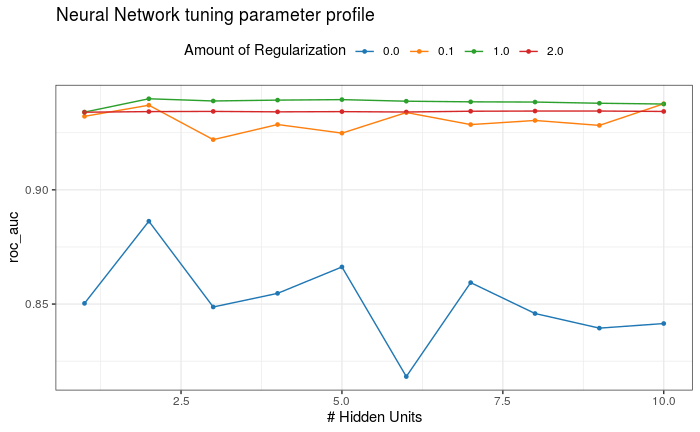

```r
# Plot AUC:
autoplot(nn_res1, metric = "roc_auc") +
  ggsci::scale_color_d3() +
  theme(legend.position = "top") +
  ggtitle("Neural Network tuning parameter profile")
```

#### Test data

```r
# Select best model:
best_mod <- nn_res1 %>%
  select_best("roc_auc")

# Update final workflow:
final_wf <-
  workflow %>%
  finalize_workflow(best_mod)

# Fit final model and make predictions:
final_fit <-
  final_wf %>%
  last_fit(splits)

# Collect predictions:
test_results <-
  rbind(
    test_results,
    cbind(
      final_fit %>%
        collect_predictions(),
      model = "Neural Network"
    )
  )
```

## 13.3 Flexible Discriminant Analysis

FDA is implemented using the `discrim_flexible()` function in the `discrim` package. I will tune a FDA model using the same grid as with the `caret` model, except that I will tune over values of one and two for the degree (`prod_degree`).

#### Training data

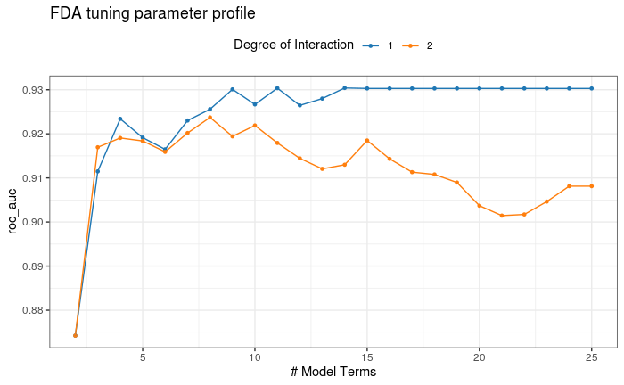

```r
# Preprocessing
rec1 <-
  recipe(y ~ ., data = df_train) %>%
  step_center(all_numeric()) %>%
  step_scale(all_numeric()) %>%
  step_nzv(all_predictors()) %>%
  step_corr(all_numeric(), threshold = 0.9) %>%
  step_dummy(all_nominal(), -all_outcomes())

# Model
fda_mod1 <-
  discrim_flexible(num_terms = tune(), prod_degree = tune()) %>%
  set_mode("classification") %>%
  set_engine("earth")

# Tuning grid
grid1 <- expand.grid(prod_degree = 1:2, num_terms = 2:25)

# Workflow
workflow <-
  workflow() %>%
  add_model(spec = fda_mod1) %>%
  add_recipe(rec1)

# Tune
### Read in cached results if available:
file1 <- "/home/brian/R/dir/APM/chapter13/objects/fda_res1_clean.RDS"
if (file.exists(file1)) {
  fda_res1 <- readRDS(file1)
} else {
  fda_res1 <-
    workflow %>%
    tune_grid(resamples = folds, grid = grid1)
  saveRDS(fda_res1, file1)
}

# Plot AUC:
autoplot(fda_res1, metric = "roc_auc") +
  ggsci::scale_color_d3() +
  theme(legend.position = "top") +
  ggtitle("FDA tuning parameter profile")
```

#### Test data

```r
# Select best model:
best_mod <- fda_res1 %>%
  select_best("roc_auc")

# Update final workflow:
final_wf <-
  workflow %>%
  finalize_workflow(best_mod)

# Fit final model and make predictions:
final_fit <-
  final_wf %>%
  last_fit(splits)

# Collect predictions:
test_results <-
  rbind(
    test_results,
    cbind(
      final_fit %>%
        collect_predictions(),
      model = "FDA"
    )
  )
```

## 13.4 Support Vector Machines

### Radial Basis Function SVM

Tune a radial basis function SVM using the same grid as with the `caret` model.

#### Training data

```r
# Preprocessing
rec1 <-
  recipe(y ~ ., data = df_train) %>%
  step_center(all_numeric()) %>%
  step_scale(all_numeric()) %>%
  step_nzv(all_predictors()) %>%
  step_corr(all_numeric(), threshold = 0.9) %>%
  step_dummy(all_nominal(), -all_outcomes())

# Model
svm_rad_mod1 <-
  svm_rbf(cost = tune(), rbf_sigma = tune()) %>%
  set_mode("classification") %>%
  set_engine("kernlab")

# Tuning grid
sigma_range <- kernlab::sigest(model.matrix(y ~ ., data = df_train)) # changed this from as.matrix() as there was an error
```

```
Variable(s) `' constant. Cannot scale data.
```

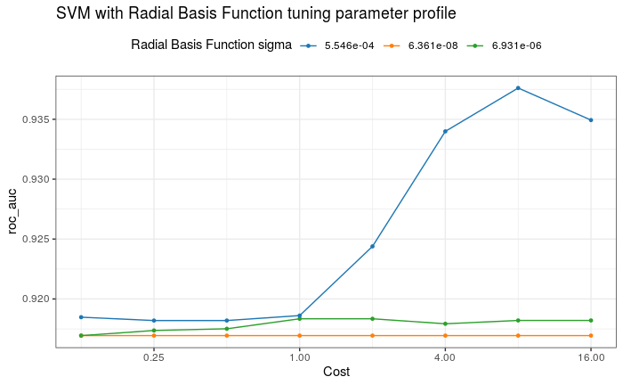

```r
grid1 <- expand.grid(rbf_sigma =  as.vector(sigma_range), # there are three values in sigma_range
                     cost = 2^(-3:4))

# Workflow
workflow <-
  workflow() %>%
  add_model(spec = svm_rad_mod1) %>%
  add_recipe(rec1)

# Tune
### Read in cached results if available:
file1 <- "/home/brian/R/dir/APM/chapter13/objects/svm_rad_res1_clean.RDS"
if (file.exists(file1)) {
  svm_rad_res1 <- readRDS(file1)
} else {
  svm_rad_res1 <-
    workflow %>%
    tune_grid(resamples = folds, grid = grid1)
  saveRDS(svm_rad_res1, file1)
}

# Plot AUC:
autoplot(svm_rad_res1, metric = "roc_auc") +
  ggsci::scale_color_d3() +
  theme(legend.position = "top") +
  ggtitle("SVM with Radial Basis Function tuning parameter profile")
```

#### Test data

```r
# Select best model:
best_mod <- svm_rad_res1 %>%
  select_best("roc_auc")

# Update final workflow:
final_wf <-
  workflow %>%
  finalize_workflow(best_mod)

# Fit final model and make predictions:
final_fit <-
  final_wf %>%
  last_fit(splits)

# Collect predictions:
test_results <-
  rbind(
    test_results,
    cbind(
      final_fit %>%
        collect_predictions(),
      model = "Radial Basis Function SVM"
    )
  )
```

### Polynomial SVM

Tune a polynomial SVM using the same grid as with the `caret` model.

#### Training data

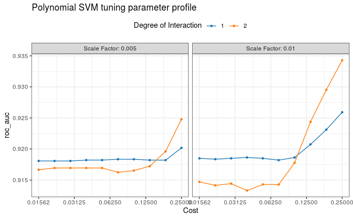

```r
# Preprocessing
rec1 <-
  recipe(y ~ ., data = df_train) %>%
  step_center(all_numeric()) %>%
  step_scale(all_numeric()) %>%
  step_nzv(all_predictors()) %>%
  step_corr(all_numeric(), threshold = 0.9) %>%
  step_dummy(all_nominal(), -all_outcomes())

# Model
svm_poly_mod1 <-
  svm_poly(degree = tune(), scale_factor = tune(), cost = tune()) %>%
  set_mode("classification") %>%
  set_engine("kernlab")

# Tuning grid
grid1 <- expand.grid(degree = 1:2,
                     scale_factor = c(0.01, 0.005),
                     cost = 2^(seq(-6, -2, length = 10)))

# Workflow
workflow <-
  workflow() %>%
  add_model(spec = svm_poly_mod1) %>%
  add_recipe(rec1)

# Tune
### Read in cached results if available:
file1 <- "/home/brian/R/dir/APM/chapter13/objects/svm_poly_res1_clean.RDS"
if (file.exists(file1)) {
  svm_poly_res1 <- readRDS(file1)
} else {
  svm_poly_res1 <-
    workflow %>%
    tune_grid(resamples = folds, grid = grid1)
  saveRDS(svm_poly_res1, file1)
}

# Plot AUC:
autoplot(svm_poly_res1, metric = "roc_auc") +
  ggsci::scale_color_d3() +
  theme(legend.position = "top") +
  ggtitle("Polynomial SVM tuning parameter profile")
```

#### Test data

```r
# Select best model:
best_mod <- svm_poly_res1 %>%
  select_best("roc_auc")

# Update final workflow:
final_wf <-
  workflow %>%
  finalize_workflow(best_mod)

# Fit final model and make predictions:
final_fit <-
  final_wf %>%
  last_fit(splits)

# Collect predictions:
test_results <-
  rbind(
    test_results,
    cbind(
      final_fit %>%
        collect_predictions(),
      model = "Polynomial SVM"
    )
  )
```

## 13.5 K-Nearest Neighbors

Tune a KNN model using a different grid to the `caret` model. As I am using cross-validation here I need a smaller max number of neighbors. I used a training/test split for the `caret` model.

#### Training data

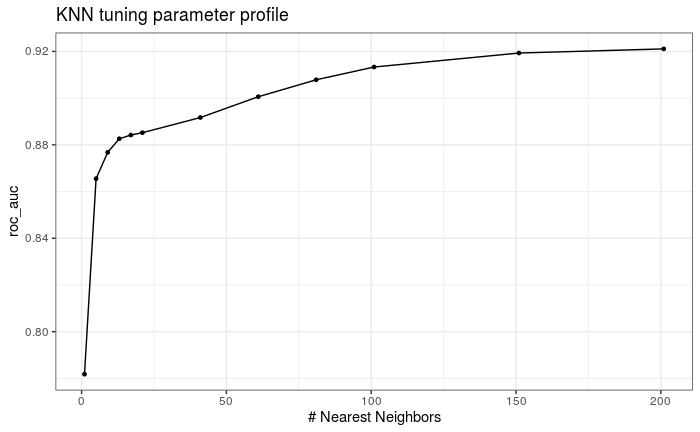

```r
# Preprocessing
rec1 <-
  recipe(y ~ ., data = df_train) %>%
  step_center(all_numeric()) %>%
  step_scale(all_numeric()) %>%
  step_nzv(all_predictors()) %>%
  step_corr(all_numeric(), threshold = 0.9) %>%
  step_dummy(all_nominal(), -all_outcomes())

# Model
knn_mod1 <-
  nearest_neighbor(neighbors = tune()) %>%
  set_mode("classification") %>%
  set_engine("kknn")

# Tuning grid
grid1 <- data.frame(neighbors = c(4*(0:5) + 1, 20*(1:4) + 1, 50*(2:4) + 1))

# Workflow
workflow <-
  workflow() %>%
  add_model(spec = knn_mod1) %>%
  add_recipe(rec1)

# Tune
### Read in cached results if available:
file1 <- "/home/brian/R/dir/APM/chapter13/objects/knn_res1_clean.RDS"
if (file.exists(file1)) {
  knn_res1 <- readRDS(file1)
} else {
  knn_res1 <-
    workflow %>%
    tune_grid(resamples = folds, grid = grid1)
  saveRDS(knn_res1, file1)
}

# Plot AUC:
autoplot(knn_res1, metric = "roc_auc") +
  ggsci::scale_color_d3() +
  theme(legend.position = "top") +
  ggtitle("KNN tuning parameter profile")
```

#### Test data

```r
# Select best model:
best_mod <- knn_res1 %>%
  select_best("roc_auc")

# Update final workflow:
final_wf <-
  workflow %>%
  finalize_workflow(best_mod)

# Fit final model and make predictions:
final_fit <-
  final_wf %>%
  last_fit(splits)

# Collect predictions:
test_results <-
  rbind(
    test_results,
    cbind(
      final_fit %>%
        collect_predictions(),
      model = "KNN"
    )
  )
```

## 13.6 Naı̈ve Bayes

Near-zero-variance predictors are removed for this model. I will use a custom grid for the `smoothness` parameter, which is equivalent to the `adjust` parameter in the `caret` model.

#### Training data

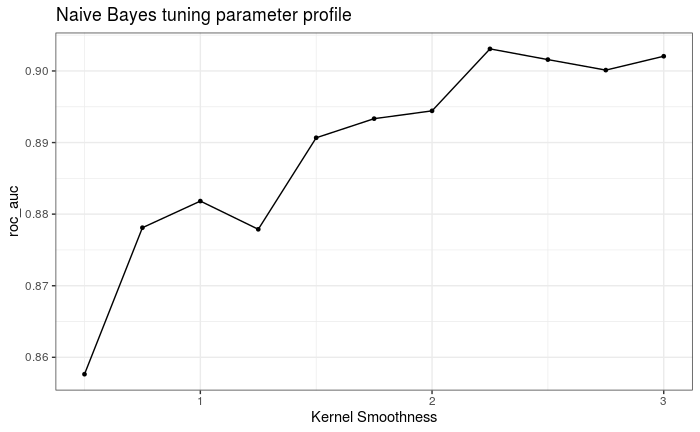

```r
# Preprocessing
rec1 <-
  recipe(y ~ ., data = df_train) %>%
  step_center(all_numeric()) %>%
  step_scale(all_numeric()) %>%
  step_nzv(all_predictors()) %>%
  step_corr(all_numeric(), threshold = 0.9) %>%
  step_dummy(all_nominal(), -all_outcomes())

# Model
nb_mod1 <-
  naive_Bayes(smoothness = tune(), Laplace = 2) %>% # just use 2 for the Laplace parameter, the same as the `caret` model
  set_mode("classification") %>%
  set_engine("klaR")

# Tuning grid
#grid1 <- grid_regular(list(smoothness = smoothness()), levels = 5)
grid1 <- data.frame(smoothness = seq(0.5, 3, 0.25)) # Since the AUC was increasing for higher smoothness, I made this alternate grid

# Workflow
workflow <-
  workflow() %>%
  add_model(spec = nb_mod1) %>%
  add_recipe(rec1)

# Tune
### Read in cached results if available:
file1 <- "/home/brian/R/dir/APM/chapter13/objects/nb_res1_clean.RDS"
if (file.exists(file1)) {
  nb_res1 <- readRDS(file1)
} else {
  nb_res1 <-
    workflow %>%
    tune_grid(resamples = folds, grid = grid1)
  saveRDS(nb_res1, file1)
}

# Plot AUC:
autoplot(nb_res1, metric = "roc_auc") +
  ggsci::scale_color_d3() +
  theme(legend.position = "top") +
  ggtitle("Naive Bayes tuning parameter profile")
```

#### Test data

```r
# Select best model:
best_mod <- nb_res1 %>%
  select_best("roc_auc")

# Update final workflow:
final_wf <-
  workflow %>%
  finalize_workflow(best_mod)

# Fit final model and make predictions:
final_fit <-
  final_wf %>%
  last_fit(splits)

# Collect predictions:
test_results <-
  rbind(
    test_results,
    cbind(
      final_fit %>%
        collect_predictions(),
      model = "Naive Bayes"
    )
  )
```

## Metrics

### Calculate metrics

```r
get_metrics <- function(test_results, model) {
  test_results <- test_results %>%
    filter(model == {{ model }})

  metrics <- caret::confusionMatrix(data = test_results$.pred_class,
                                    reference = test_results$y,
                                    positive = "yes")

  metrics$auc <-
    test_results %>%
    yardstick::roc_auc(y, .pred_yes, event_level = "first") %>% # *1
    pluck(".estimate")

  return(metrics)
}

models <- unique(test_results$model)
metrics <- map(models, ~get_metrics(test_results, .x)) %>%
  set_names(models)

# *1: event_level not required but added for clarity. It refers to the first level in the levels of the response. Since "yes" is the target and the first level, I have set those arguments here. It was different for the churn model in APM_12_exercise_12.3.Rmd because "yes" was the second level but the important thing is to be consistent. Same thing with the ROC curves and lift/gain charts below.
```

### Inspect metrics

#### AUC

Area under ROC curve:

```r
# Display a named list of metrics as a table as opposed to a vector:
bh_display_metric <- function(metrics, type = "Metric") { # metrics is a named vector of doubles
  M <- matrix(metrics)
  dimnames(M) <- list(names(metrics), type)
  return(M)
}
bh_display_metric(map_dbl(metrics, ~.x$auc) %>% sort(decreasing = T), type = "Test AUC")
```

```
                          Test AUC
FDA                         0.9271
Regularized LDA             0.9042
Neural Network              0.9018
Polynomial SVM              0.8992
Radial Basis Function SVM   0.8989
KNN                         0.8902
Naive Bayes                 0.8899
QDA                         0.8275
```

#### Accuracy

```r
bh_display_metric(map_dbl(metrics, ~.x$overall[1]) %>% sort(decreasing = T), type = "Test Accuracy")
```

```
                          Test Accuracy
Regularized LDA                  0.8528
Neural Network                   0.8528
FDA                              0.8528
Radial Basis Function SVM        0.8528
Polynomial SVM                   0.8221
Naive Bayes                      0.8098
KNN                              0.8037
QDA                              0.7239
```

#### Sensitivity

```r
bh_display_metric(map_dbl(metrics, ~.x$byClass[1]) %>% sort(decreasing = T), type = "Test Sensitivity")
```

```
                          Test Sensitivity
FDA                                 0.9189
Radial Basis Function SVM           0.8919
Naive Bayes                         0.8784
Regularized LDA                     0.8514
Neural Network                      0.8514
Polynomial SVM                      0.7568
KNN                                 0.6216
QDA                                 0.5135
```

### ROC Curves

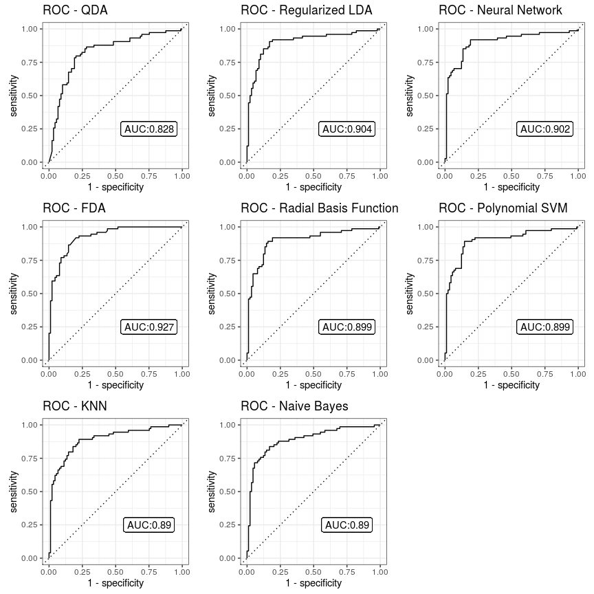

```r
# Returns an ROC curve for a given model:
plot_roc_curve <- function(test_results, model) {

  # Get AUC for labeling the plot:
  auc <- metrics[[{{ model }}]]$auc

  # ROC curve:
  p <- test_results %>%
    filter(model == {{ model }}) %>%
    yardstick::roc_curve(y, .pred_yes, event_level = "first") %>%
    autoplot() +
    geom_label(aes(x = 0.75, y = 0.25, label = paste0("AUC:", round(auc, 3)))) +
    ggtitle(paste0("ROC - ", {{ model }}))
  return(p)
}

cowplot::plot_grid(
  plotlist = map(models, ~plot_roc_curve(test_results, .x))
)
```

### Gain Curves

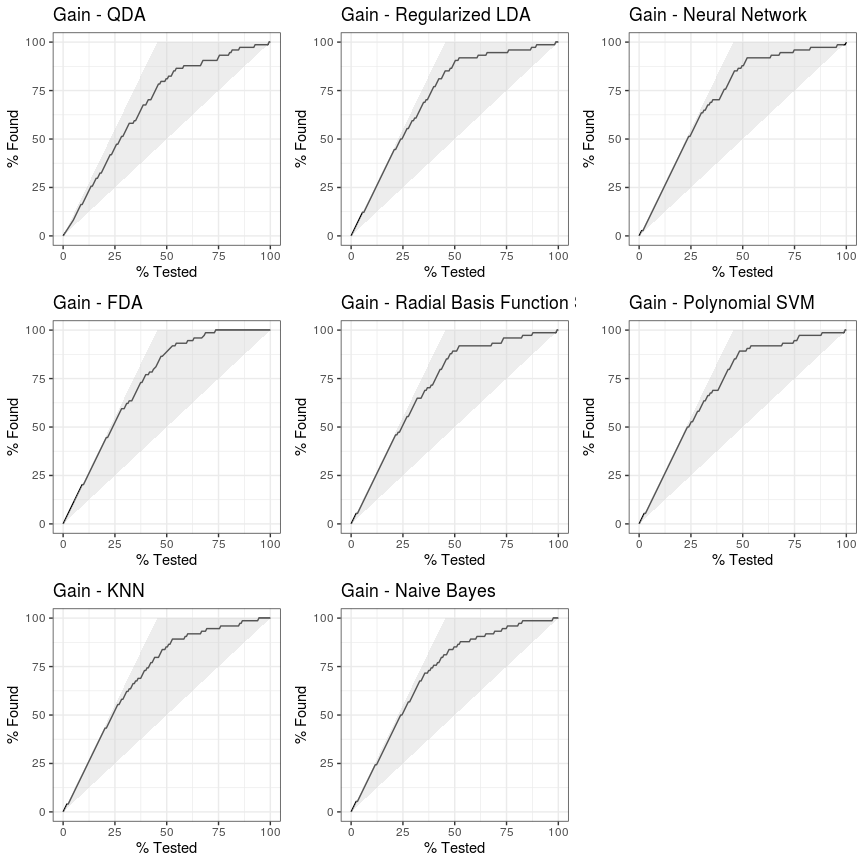

```r
# Returns a gain curve for a given model:
plot_gain_curve <- function(test_results, model) {

  # Gain curve:
  p <- test_results %>%
    filter(model == {{ model }}) %>%
    yardstick::gain_curve(y, .pred_yes, event_level = "first") %>%
    autoplot() +
    ggtitle(paste0("Gain - ", {{ model }}))
  return(p)
}

cowplot::plot_grid(
  plotlist = map(models, ~plot_gain_curve(test_results, .x))
)
```

### Lift Curves

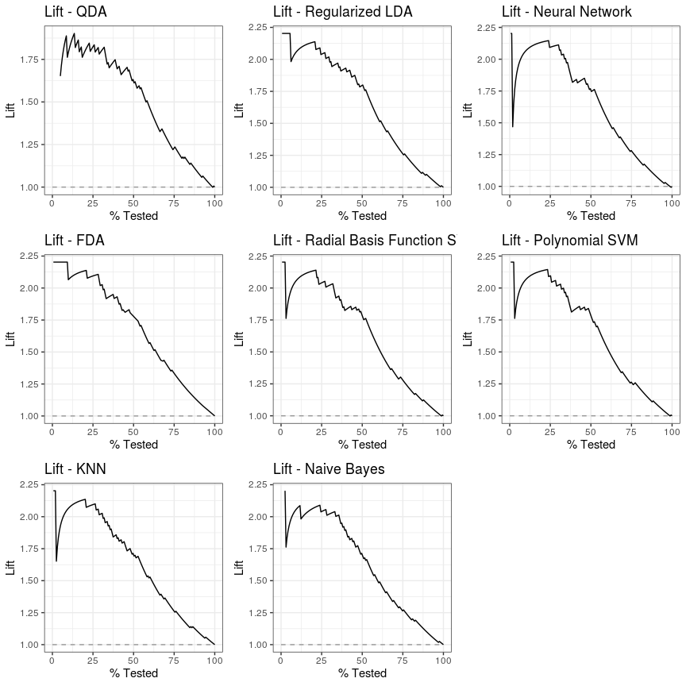

[^1]: Kuhn M, Johnson K (2013). *Applied Predictive Modeling*. Springer.
[^2]: https://archive.ics.uci.edu/ml/datasets/Credit+Approval